# Modelling a Hospital Queuing System - STAT2005 Project

**NoteLink to GitHub:**

https://kesia-31.github.io/STAT2005/STAT2005_Quarto.html

**Contributers:**

Harshitha Bhupathiraju - 21478222

Rithika Suresh Kumar - 22931108

Kesia James - 20944201

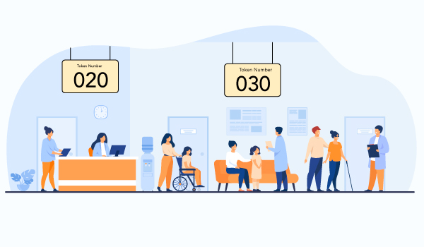

Hospital Queueing - (Queue Management System in Hospitals and Clinics, 2021)

## 1 Introduction and Background

### 1.1 Problem context

Healthcare systems rely on appointment-based scheduling systems to manage patient demand and allocate limited medical resources efficiently. Ensuring smooth patient flow and optimising the use of medical resources is critical to maintain high quality care and patient satisfaction.

However, operational challenges such as long patient waiting times, and limited staff can reduce clinic efficiency and hinder timely access to healthcare services. While missed appointments lead to poor utilisation of resources, not having sufficient staff can result in excessive waiting times.

Long waiting times are a significant operational issue. Excessive delays can negatively impact patient satisfaction, increase stress for both patients and staff, and can reduce the overall quality of care, particularly in high-demand clinics where appointment slots are limited. (Khaled Falah Alrasheedit et al., 2019). Waiting times are often influenced by factors such as appointment scheduling and clinic workload, and can also be exacerbated by occasional missed scheduled appointments, commonly referred to as no-shows. Research (Leila F. Dantas et al., 2018) reports that the average ‘no-show’ rate is around 23%, across all medical specialties. Scheduling inefficiencies create a cycle of delay that is difficult to manage. Therefore, no-show behaviour is an important factor to consider when analysing patient flow, as it directly affects resource utilisation and waiting times.

Limited staff availability further strains a clinic’s ability to manage these operational challenges. When clinics operate with fewer healthcare professionals than required, appointment delays and waiting times increase. Staff shortages not only reduce the clinic’s ability to respond to patient demand, but also limits the flexibility needed to manage no-shows effectively, therefore impacting both operational efficiency and patient satisfaction.

### 1.2 Objectives

For this project, the dataset intended to be used is the ‘Medical Appointment Scheduling System’ data sourced from Kaggle (María Carolina Gonzalez Galtier, 2025). It contains approximately 111,000 synthetic records, where each row represents a scheduled appointment. The dataset contains information relating to appointment date and timing, waiting time, and whether the patient attended the appointment or not.

Our aim is to investigate how the number of doctors present at the clinic affects patient waiting times and hence calculate the minimum number of doctors needed at the clinic to maintain the average waiting time under 30 minutes.

Specifically, this study seeks to quantify the relationship between staffing levels and waiting times, to allow for optimal doctor allocation.

### 1.3 Significance

By investigating the number of doctors present at a clinic, we can help healthcare providers improve clinic performance and service. This could include adjusting staff allocation based on patient demand and scheduling to minimise queues and congestion during peak periods.

Reducing wait times can contribute to a better experience for the patient and also make the work environment easier for staff by reducing pressure and helping the clinic run more smoothly throughout the day. If healthcare providers can understand the general patterns revolving workflow issues, more informed scheduling decisions can be made, hence better utilising available resources. This can therefore improve operational efficiency, reduce wait times, and enhance patient satisfaction.

Overall, this study uses data to help improve how clinics operate. It supports better decision making regarding staffing and appointment scheduling, which can therefore lead to shorter waiting times, more efficient use of resources, and improved quality of care for all patients.

### 1.4 Literature review

Previous research has consistently shown operational efficiencies as a key challenge in healthcare systems. Studies such as Alrasheedit et al. (2019) demonstrate that prolonged waiting times are strongly associated with reduced patient satisfaction and the perceived quality of care. Similarly, Dantas et al. (2018) highlights the impact of patient no-shows on scheduling efficiency and the use of resources across medical specialties. Dantas et al. (2018) also highlights how missed appointments lead to a substantial waste of medical resources, such as healthcare staff time, facilities, and operational costs. Research on outpatient scheduling further highlights the importance of balancing patient demand with available capacity to minimise delays (Gupta & Denton, 2008).

Moreover, Samel (2025) emphasises that a lack of healthcare staff results in increased patient waiting times. Samel (2025) also emphasises how insufficient staffing is associated with more errors, patient complications and a general reduction in the quality of care that can be delivered to the client. Thus, this reiterates the importance of having enough doctors to have waiting times within an acceptable limit of patients receiving maximum care and utilisation of appointments.

Previous research in hospital queue modelling has been done by Ocampo Osorio et al. (2025), through the development of machine learning models to predict the risk of patient no-shows. This study shows how no-show behaviour follows clear patterns, hence further reinforcing how important it is to take patient no-shows into account while simulating a model of healthcare clinic operations.

While existing literature has acknowledged that scheduling practices and patient behaviour affects clinical performance, there are fewer studies focusing on determining the most optimal staffing levels. In particular, there is scope for further research that links staffing directly to acceptable waiting times.

## 2 Methodology

### 2.1 Model Formulation

This project models the healthcare appointment system by using a queuing simulation approach. Initially, a G/G/1 queue is developed to represent a single doctor system, which is then extended to a G/G/c model to simulate multiple doctors within the clinic.

Queuing theory models a system that changes in accordance to a sequence of events. Within the context of the hospital settings, these events are:

1. The arrival of patients
2. How patients are seen
3. The number of servers

**Important**

A G/G/1 queue is characterised by:

- Inter-arrival times: $T_a$ which follows a general distribution
- Service times: $T_s$ which follows a general distribution
- Number of servers: $c = 1$

To extend this to a G/G/c model, the number of servers should be $c > 1$

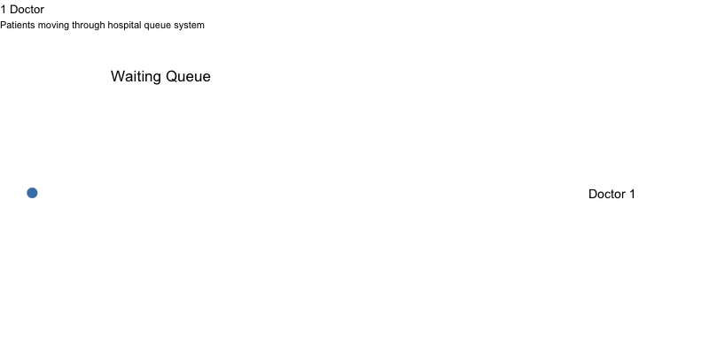

Visualisation of a one doctor queue

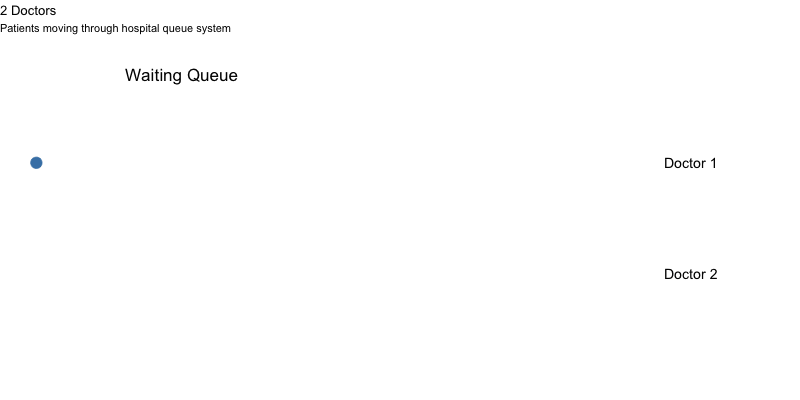

Visualisation of two-doctor queue

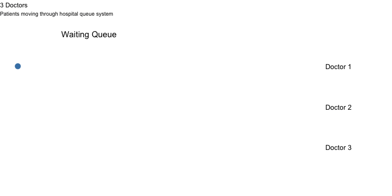

Visualisation of three-doctor queue

Patient arrivals are modelled using inter-arrival times calculated from the difference between two sequential patients’ check-in times. These inter-arrival times are assumed to follow a fitted probability distribution (such as Log-Normal or Exponential).

Within the model, each arrival will be calculated as:

$$T_i = T_{i-1} + T_{a}^{(i)}, \quad i = 1, 2, \ldots, n$$

Where $T_i$ is the arrival time of the i-th patient, calculated as $T_a^{(i)}$ (a randomly sampled inter-arrival time) added to the arrival time of the previous patient ($T_{i-1}$).

Service times $\{T_s^{(1)}, T_s^{(2)}, \ldots, T_s^{(n)}\}$ are defined as the duration of each appointment and are also modelled using an appropriate fitted distribution based on the dataset.

The model assumes that only patients who attend their appointments contribute to the queue, with no-show behaviour incorporated by assigning each patient a probability of attendance. Only patients who attend their appointments contribute to the queue, while patients who do not attend or cancel their appointment are treated as no-shows and are removed from the system.

This will be achieved by bernoulli sampling where:

$$Attendance = \begin{cases} 1 & : p \\ 0 & : 1-p \end{cases}$$

where p = 0.772 (the empirically estimated attendance probability)

Calculating the strength of the model can be done through numerous metrics. Most notably, the **utilisation ratio** $(\rho)$, calculated as:

$$\rho = \frac{\lambda}{c\mu}$$

Where $\lambda$ is the arrival rate and $\mu$ is the service rate. If $\rho$ < 1, this indicates a stable process wherein the system will not grow indenifinitely as patients are treated at a faster rate than they arrive.

To calculate the theoretical metrics of our G/G/1 queuing model, the **Kingman Approximation** returns an approximation of waiting times based on the utilisation and variance of the queue.

$$E(W) = \frac{\rho}{(1-\rho)} \times (\frac{C^2_a + C^2_s}{2}) \times E[T_s]$$

Due to the nature of the waiting times and inter-arrival times following non-exponential distributions, this approximation will compute more realistic baseline measures to compare the simulation’s performance to. This approximation can then be used to calculate other informative metrics, such as **Response Time (**$W$), **Waiting Time (**$W_q$), **Average number of patients in the queue** **(**$L_q$), **Average number of patients in the system** **(**$L$) and **The proportion of time the system is empty** **(**$P_0$).

Assumptions for model implementation:

- Patient arrivals are based on inter-arrival times calculated from consecutive patients’ check-in times, allowing for variability in arrival patterns, including peak periods.
- Inter-arrival times follow a fitted probability distribution to reflect the randomness observed in real patient arrival times.
- Service time is defined as the appointment duration, and varies between patients, meaning not all appointments take the same amount of time.
- Each doctor can treat only one patient at a time.
- Patients who attend join a single queue and are served in order of arrival (first-come, first-served).
- Each patient has a probability of attendance, and patients who do not attend or cancel their appointment are treated as no-shows and removed from the system, meaning they do not join the queue or require service.
- Queue capacity is assumed to be unlimited (no patients are turned away)
- All doctors are assumed to have the same service capability

**NoteModel Types:**

1. **G/G/1 Model** - To understand how patient arrival rates affect waiting times
2. **G/G/c Model** - To analyse how increasing doctors reduces waiting times

### 2.2 Description of data

The data-set to be used for this queuing model is the ‘Medical Appointment Scheduling System’ data-set sourced from Kaggle. This data-set contains synthetic records related to the healthcare appointment system with 111488 observations. Due to the data-set being synthetically generated, no significant cleaning/handling of missing observations must occur.

```r
#reading in the dataset
appointments <- read.csv("appointments.csv")
head(appointments, n=2)
```

```
  appointment_id slot_id scheduling_date appointment_date appointment_time
1            138       1      2014-12-28       2015-01-01         08:00:00
2            146      23      2014-12-29       2015-01-01         13:30:00
  scheduling_interval         status check_in_time appointment_duration
1                   4 did not attend                                 NA
2                   3 did not attend                                 NA
  start_time end_time waiting_time patient_id  sex age age_group
1                               NA       8285 Male  37     35-39
2                               NA       5972 Male  84     80-84
```

However, the data will be condensed to **appointments_clean** which contains only the required variables of appointment_datetime, waiting_time, appointment_duration and status.

To extract the required information to develop the queuing model, inter-arrival times will be calculated by first combining appointment_date and check_in_time to then sort all appointments chronologically. To prevent ‘no-shows’ from impacting the distribution of waiting times and inter-arrival times, they will be filtered from the initial distribution fitting stage to develop accurate parameters, but the proportion of ‘no-shows’ will be calculated to later inform the queuing model.

To factor in the no-shows as part of the simulation, the ‘no-show’ rate should be calculated.

```r
# calculating no-show rate
no_shows <- appointments$status != 'attended'
no_show_rate <- nrow(appointments[no_shows,]) / nrow(appointments)
no_show_rate
```

```
[1] 0.2283295
```

Summary statistics for the cleaned dataset can be seen below.

Summary Statistics for the cleaned dataset

| Variable | N | Mean | Std. Dev. | Min | Pctl. 25 | Pctl. 75 | Max |
| --- | --- | --- | --- | --- | --- | --- | --- |
| appointment_duration | 86032 | 17 | 11 | 0 | 8.6 | 25 | 59 |
| inter_arrival | 83445 | 18 | 13 | 0 | 8.2 | 26 | 113 |
| waiting_time | 86032 | 44 | 41 | 0.6 | 13 | 65 | 297 |
| status | 86032 |  |  |  |  |  |  |
| ... attended | 86032 | 100% |  |  |  |  |  |

### 2.3 Justification of modelling choices

A queuing simulation approach has been chosen since healthcare appointment systems naturally operate as stochastic service systems, where the patient arrivals, waiting, and service occur at random. This makes the queuing theory an appropriate framework for analysing clinical performance.

The G/G/1 and G/G/c models have been selected due to their flexibility in allowing general distributions for both inter-arrival and service times. This is important since real-world healthcare data will rarely follow an exact distribution, and instead will contain variability in both the arrival patterns and duration of the appointments.

Inter-arrival times and service times have been selected as the primary modelling inputs as they directly impact the queuing dynamics including congestion, waiting times, and the use of resources. These variables are therefore essential for evaluating the impact of staffing level on clinical efficiency.

A simulation-based approach is preferred over analytical queuing solutions because real healthcare systems will involve unpredictable behaviours including variable arrival rates and patient no-shows. Using simulation will allow for these events to be modelled instead of relying on a strict mathematical model.

Distribution fitting will be used for both the inter-arrival times and service times to ensure that the model accurately reflects the dataset. This will improve the accuracy and validity of the simulation compared to assuming theoretical distributions. No-show patients are excluded from the distribution fitting to avoid bias in the estimation of arrival and service times.

## 3 Model Implementation and Results

### 3.1 Exploratory Data Analysis

Exploratory data analysis is conducted to visually understand the important parameters of the dataset. Through information gleaned from the aid of generated plots, consequent distribution fitting was allowed to occur.

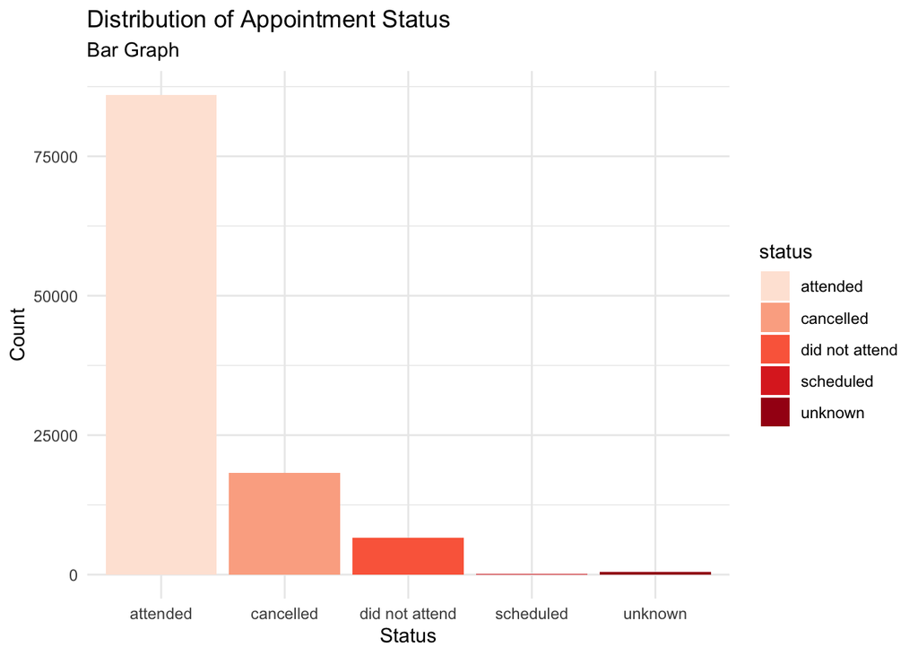

(a)

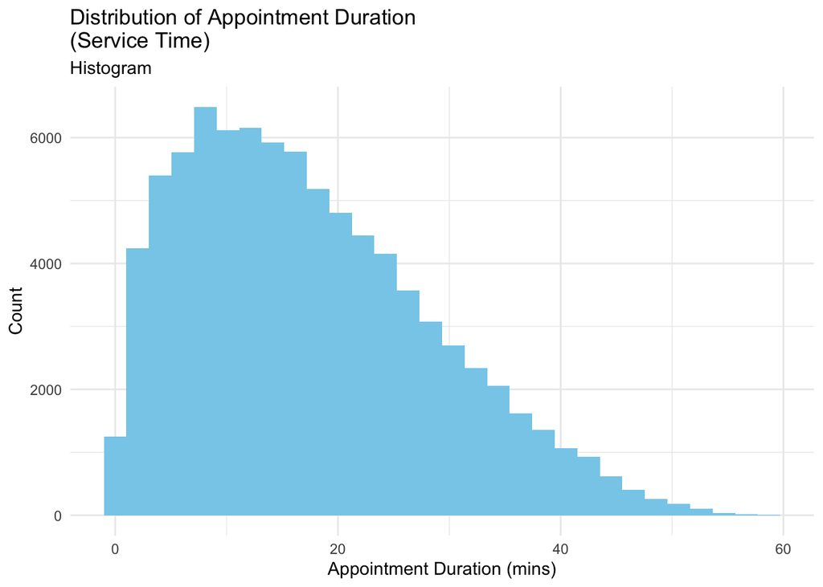

(b)

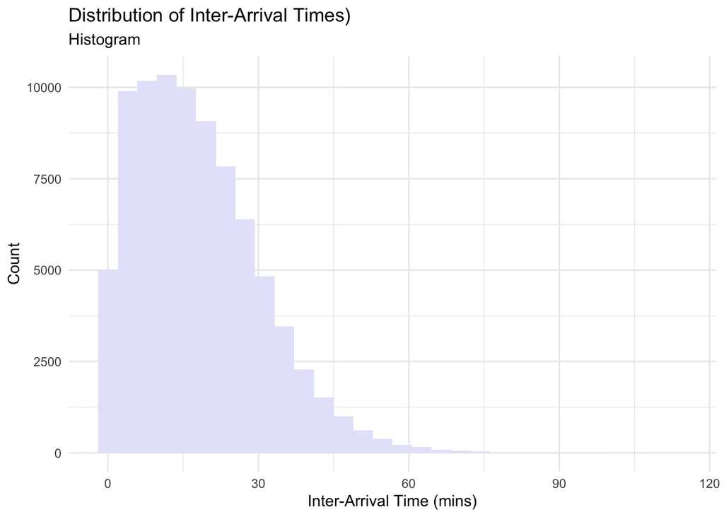

(c)

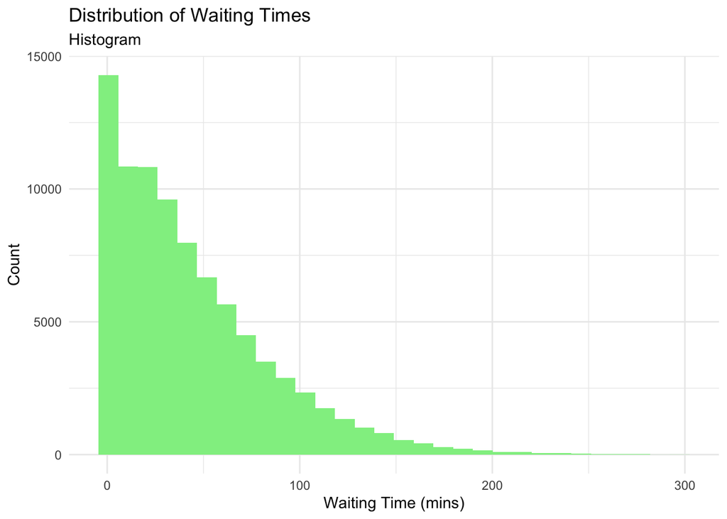

(d)

Figure 1: Plots for Explanatory Data Analysis

```r
library(ggplot2)

# plotting appointment status
appointments %>% ggplot(aes(x=status, fill=status)) +
  geom_bar() +
  labs(title="Distribution of Appointment Status",
       subtitle='Bar Graph',
       x='Status',
       y='Count') +
  theme(plot.title = element_text(face="bold"),
        axis.title = element_text(size = 80)) +
  scale_fill_brewer(palette="Reds") +
  theme_minimal()

# plotting appointment duration
appointments_clean %>% ggplot(aes(x=appointment_duration)) +
  geom_histogram(fill="skyblue", bins=30) +
  labs(title="Distribution of Appointment Duration \n(Service Time)",
       subtitle='Histogram',
       x='Appointment Duration (mins)',
       y='Count') +
  theme(plot.title = element_text(face="bold"),
        axis.title = element_text(size = 80)) +
  theme_minimal()

# plotting inter-arrival times
ggplot(data.frame(inter_arrivals),aes(x=inter_arrivals)) + geom_histogram(fill="lavender", bins=30) +
  labs(title="Distribution of Inter-Arrival Times)",
       subtitle='Histogram',
       x='Inter-Arrival Time (mins)',
       y='Count') +
  theme(plot.title = element_text(face="bold"),
        axis.title = element_text(size = 80)) +
  theme_minimal()

# plotting waiting times
appointments_clean %>% ggplot(aes(x=waiting_time)) +
  geom_histogram(fill="lightgreen", bins=30) +
  labs(title="Distribution of Waiting Times",
       subtitle='Histogram',
       x='Waiting Time (mins)',
       y='Count') +
  theme(plot.title = element_text(face="bold"),
        axis.title = element_text(size = 80)) +
  theme_minimal()
```

Figure 1 (a) shows the distribution of appointment status in which the majority of appointments were attended, with approximately 85,000 completed appointments recorded in the dataset. A smaller proportion of appointments were cancelled or marked as “did not attend”, and very few appointments remained scheduled or unknown. Though this indicates that most of the patients contributed to the healthcare queueing system, the presence of cancellations and no-shows suggests that attendance behaviour must still be incorporated into the simulation model.

Figure 1 (b) shows a histogram of appointment durations (service times) that displays a positively skewed distribution, with most of the appointments concentrated around shorter durations of approximately 8-10 minutes and fewer longer appointments extending into the right tail of the distribution. This indicates that service times are not constant and contain significant variability, which supports the use of a service-time distribution within the G/G/1 and G/G/c queueing models rather than assuming deterministic service times.

Figure 1 (c) shows the distribution of inter-arrival times which also shows a strong right-skewness, with a peak around 12-13 minutes and a long right tail representing occasional larger gaps between patient arrivals. This suggests that patient arrivals occur irreguarly rather than at constant intervals, further justifying the use of general arrival distributions within the simulation model. The observed shape appeared consistent with distributions such as the Weibull or Log-Normal distribution, which are capable of modelling skewed non-negative data.

Finally, Figure 1 (d) shows the distribution of waiting times as similarly positively skewed, with a high frequency of shorter waiting times and fewer extremely long waits. This behaviour is typical of congested queuing systems, where most patients experience moderate delays while a smaller number of patients experience substantially longer waiting times due to periods of increased queue congestion. The skewed nature of the waiting times indicates that average waiting time alone may not fully describe system performance, making additional measures such as maximum waiting times and queue lengths important for evaluating the healthcare system.

### 3.2 Distribution Fitting:

Distribution Fitting can be done via the ‘fitdistrplus’ package available inside of R.

**INTER-ARRIVAL TIMES:**

```r
# remove NA and negative values
inter_arrivals <- na.omit(appointments_clean$inter_arrival)
inter_arrivals <- inter_arrivals[inter_arrivals > 0]

# fitting possible distributions
fit_exp_i <- fitdist(inter_arrivals, distr="exp")
fit_lognorm_i <- fitdist(inter_arrivals, distr="lnorm")
fit_weibull_i <- fitdist(inter_arrivals, distr="weibull")
fit_gamma_i <- fitdist(inter_arrivals, distr="gamma")

# calculating metrics of fit
gofstat(list(fit_exp_i, fit_lognorm_i, fit_weibull_i, fit_gamma_i))
```

```
Goodness-of-fit statistics
                                1-mle-exp  2-mle-lnorm 3-mle-weibull
Kolmogorov-Smirnov statistic    0.1189781    0.1115312    0.03450257
Cramer-von Mises statistic    487.0122614  404.9965677   35.85308405
Anderson-Darling statistic   2530.1509637 2386.1251640  234.73197267
                              4-mle-gamma
Kolmogorov-Smirnov statistic   0.05721458
Cramer-von Mises statistic    97.94120876
Anderson-Darling statistic   548.40029508

Goodness-of-fit criteria
                               1-mle-exp 2-mle-lnorm 3-mle-weibull 4-mle-gamma
Akaike's Information Criterion  649308.0    666874.8      637851.2    640933.8
Bayesian Information Criterion  649317.4    666893.5      637869.9    640952.4
```

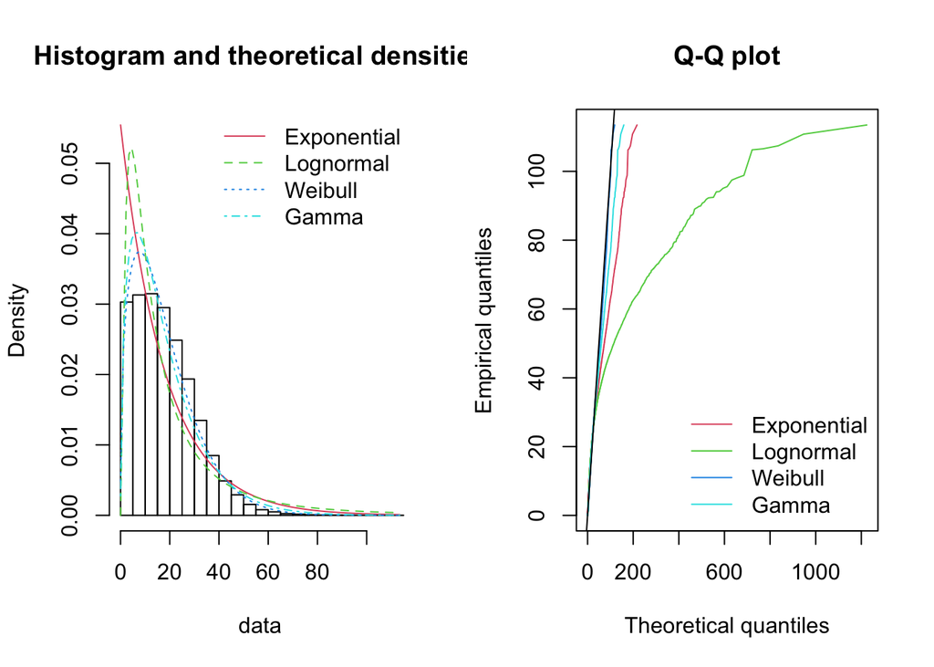

Figure 2: Plots for Distribution Fitting of Inter-Arrival Times

**SERVICE TIMES:**

```r
service_times <- na.omit(appointments_clean$appointment_duration)
service_times <- service_times[service_times > 0]

# fitting possible distributions
fit_exp_s <- fitdist(service_times, distr="exp")
fit_lognorm_s <- fitdist(service_times, distr="lnorm")
fit_weibull_s <- fitdist(service_times, distr="weibull")
fit_gamma_s <- fitdist(service_times, distr="gamma")

# compare distributions
gofstat(list(fit_exp_s, fit_lognorm_s, fit_weibull_s, fit_gamma_s))
```

```
Goodness-of-fit statistics
                               1-mle-exp  2-mle-lnorm 3-mle-weibull
Kolmogorov-Smirnov statistic    0.141574 8.591411e-02    0.02179842
Cramer-von Mises statistic    726.737994 2.457479e+02   13.32252449
Anderson-Darling statistic   4009.851855 1.520029e+03   98.78314535
                              4-mle-gamma
Kolmogorov-Smirnov statistic   0.04172027
Cramer-von Mises statistic    52.74557415
Anderson-Darling statistic   325.72243070

Goodness-of-fit criteria
                               1-mle-exp 2-mle-lnorm 3-mle-weibull 4-mle-gamma
Akaike's Information Criterion  664243.3    663115.1      641648.1    644959.9
Bayesian Information Criterion  664252.7    663133.8      641666.8    644978.7
```

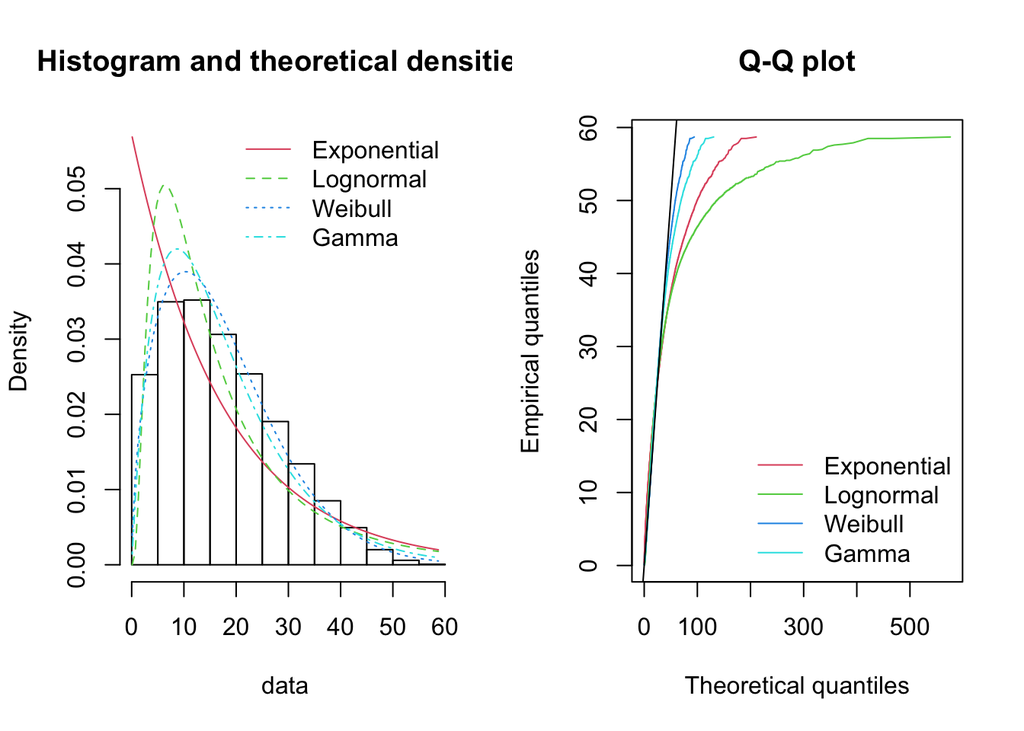

Figure 3: Plots for Distribution Fitting of Service Times

The **Weibull** **distribution** provided the best fit for both the inter-arrival times and service times based on both statistical and graphical methods. Based on both goodness-of-fit statistics and the information criteria (AIC and BIC), the Weibull distribution provided the best fit for inter-arrival times by achieving the lowest values across all metrics. This result was further supported by the density and Q-Q plots, which showed a strong correlation between the empirical data and the fitted Weibull distribution, indicating a better overall fit compared to the Exponential, Log-Normal, and Gamma distributions.

The Q-Q plots of Figure 2 and Figure 3 further supported this conclusion, with the Weibull model showing near-linear alignment across most quantiles and only minor deviations in the upper tail, while the Log-Normal model exhibited clear curvature indicating unalignment. The Exponential and Gamma models showed moderate alignment but with a greater spread from the reference line as opposed to the Weibull model.

As such, we can define the final distributions of inter-arrival times and service times respectively:

$$T_a \sim Weibull(\beta = 1.34, \alpha = 19.62):\
T_a\ = inter-arrival\ times$$

$$T_s \sim Weibull(\beta = 1.58, \alpha = 19.42)
:\ T_s\ = service\ times$$

Although the Weibull distribution provided the best statistical fit according to goodness-of-fit measures, this doesn’t necessarily make the most accurate representation of system behaviour. The simulation results suggest that a good statistical distribution fit does not guarantee realistic queue dynamics, particularly when there is a lot of variability in arrival and service times in regard to congestion formation. In this case, empirical sampling better preserves the underlying variability of the system, leading to more realistic waiting time behaviour. Empirical sampling draws straight from the dataset, rather than relying on a fitted distribution, likely reflecting the true variability of the observed data more closely.

### 3.3 Simulation

**G/G/1**

Once settling on the distributions of inter-arrival times and service times, the G/G/1 queue can be implemented, which has been adapted from ‘Stochastic Modelling’ (Sam Wiwatanapataphee, 2026)

The G/G/1 algorithm keeps track of arrival, departure and waiting times and simulates the hospital queue by:

1. Initialising the first arrival
2. Generating new arrivals until the number of patients to be simulated is reached
3. Skipping patients that are ‘no-shows’
4. Drawing inter-arrival and appointment duration times from the Weibull distribution
5. Updating the server/doctor’s state, where patients can immediately be served if the doctor is idle or join the queue if not.

When simulating the resulting queue for 10000 consecutive patients, the following mean and maximum waiting times can be calculated when sampling from the Weibull distribution for both inter-arrival and appointment duration times.

```r
# G/G/1 Queue Simulation - Weibull

# Weibull parameters for inter-arrival times and service times
shape_inter <- fit_weibull_i$estimate["shape"]
scale_inter <- fit_weibull_i$estimate["scale"]


shape_service <- fit_weibull_s$estimate["shape"]
scale_service <- fit_weibull_s$estimate["scale"]


set.seed(123)

# number of patients to simulate
sim_patients <- 10000

# no-show generation
attends <- rbinom(sim_patients, 1, 1 - no_show_rate)

# system variables
X <- 0    # number of patients in the system
T <- 0    # time

arrival_times <- c()
departure_times <- c()
waiting_times <- c()

time_vec <- c(0)
state_vec <- c(0)
event_vec <- c("Start")

# first arrival
T_a <- rweibull(
  1,
  shape = shape_inter,
  scale = scale_inter
)

# no service initially until first patient arrives
T_s <- Inf

queue_arrivals <- c()

patient <- 0

# running loop until target patients reached
while (patient < sim_patients) {

  # arrival event occurs
  if (T_a < T_s) {

    T <- T_a

    patient <- patient + 1

    # next arrival
    T_a <- T + rweibull(
      1,
      shape = shape_inter,
      scale = scale_inter
    )

    # skip no-shows
    if (attends[patient] == 0) {
      next
    }

    # doctor is now seeing patient + logging arrival time
    X <- X + 1

    arrival_times <- c(arrival_times, T)

    event_vec <- c(event_vec, "Arrival")
    time_vec <- c(time_vec, T)
    state_vec <- c(state_vec, X)

    # if the server idle, patient is immediately seen
    if (X == 1) {

      waiting_times <- c(waiting_times, 0)

      # generate appointment duration
      service_time <- rweibull(
        1,
        shape = shape_service,
        scale = scale_service
      )

      T_s <- T + service_time

    } else {

      queue_arrivals <- c(queue_arrivals, T)
      # the doctor is busy, so patient must join the queue

    }

  } else {

    # patient is leaving + logging departure event
    T <- T_s

    X <- X - 1

    departure_times <- c(departure_times, T)

    event_vec <- c(event_vec, "Departure")
    time_vec <- c(time_vec, T)
    state_vec <- c(state_vec, X)

    # queue not empty
    if (X > 0) {

      next_customer <- queue_arrivals[1]

      wait <- T - next_customer

      waiting_times <- c(waiting_times, wait)

      queue_arrivals <- queue_arrivals[-1]

      service_time <- rweibull(
        1,
        shape = shape_service,
        scale = scale_service
      )

      T_s <- T + service_time

    } else {

      T_s <- Inf

    }
  }
}

# returning data frame of time, state of system and event.
events_df <- data.frame(
  time = time_vec,
  state = state_vec,
  event = event_vec
)
```

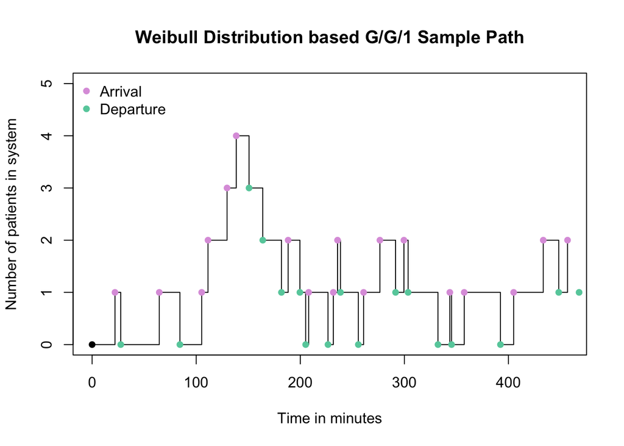

Figure 4: Sample 1-day plotting path for Weibull G/G/1 queue

Figure 4 shows the number of patients in the G/G/1 queue over time using inter-arrival and service times generated from the fitted Weibull distributions. The stepwise structure indicates that the system operates through discrete arrival times departure events, where upward movements correspond to arrivals and downward movements correspond to departures.

The system is predominantly in a low-congestion state, with most of the observations between 0 and 2 patients, and only occasional short periods where the queue increases from 3 to 4 patients. This indicates that while transient congestion occurs, the system remains stable without sustained queue growth.

The short periods of increased queue length, particularly around 100 to 160 minutes, arise when arrivals occur in quick succession relative to service completions, reflecting inherent variability in the arrival and service processes. These bursts are followed by periods where departures exceed arrivals, allowing the system to return to an empty or near-empty state.

The repeated return to zero patients suggests that the server idle at that time, indicating that the demand is below the full capacity. Overall, the sample path highlights the stochastic and time-varying nature of congestion in queueing systems driven by variability in arrivals and service times.

Actual vs Weibull Queue Simulated Mean and Maximum Waiting times

| Metrics | Theoretical | Simulation |
| --- | --- | --- |
| Mean Wait | 44.08651 | 24.75185 |
| Max Wait | 297.30000 | 266.83483 |

Table 1: Comparison of Mean and Maximum waiting times of Actual System vs Weibull-based Queue Simulation

The large discrepancy in mean wait times of 24.75 minutes for the simulation against the empirical wait time of 44.09 minutes indicates that the Weibull distribution may not accurately reflect the variability of inter-arrival times and appointment durations. As queuing systems can be quite vulnerable to variability, sampling from the Weibull distribution may have resulted in the simulation greatly underestimating wait times.

To test the quality of the simulation, test metrics such as the utilisation ratio (rho) and other performance metrics can be calculated.

```r
# Theoretical metrics using Kingsman Aprroximation:
lambda <- 1/mean(inter_arrivals)
mu <- 1/mean(appointment_duration)
rho <- lambda / mu

ca2 <- var(inter_arrivals) / mean(inter_arrivals)^2
cs2 <- var(appointment_duration) / mean(appointment_duration)^2

Wq_theory <- (rho / (mu * (1 - rho))) * ((ca2 + cs2) / 2)
Lq_theory <- lambda * Wq_theory
W_theory  <- Wq_theory + 1/mu
L_theory  <- lambda * W_theory
P0_theory <- 1 - rho

# Simulation performance metrics
durations <- diff(events_df$time) # time spent in each interval

states <- events_df$state[-nrow(events_df)]   # state held over each interval

rho_hat <- sum((states > 0) * durations) / sum(durations)
L_hat <- sum(states * durations) / sum(durations)
Lq_hat <- L_hat - rho_hat
W_hat <- L_hat / lambda
Wq_hat <- W_hat - 1 / mu
P0_hat <- sum((states == 0) * durations) / sum(durations)

weibull_metrics <- data.frame(
  Metric = c("Utilisation", "Avg. number in system", "Avg. number in queue", "Avg. response time", "Avg. waiting time", "System empty probability"),
  Theoretical = c(rho, L_theory, Lq_theory, W_theory, Wq_theory, P0_theory),
  Simulated = c(rho_hat, L_hat, Lq_hat, W_hat, Wq_hat, P0_hat))

kable(weibull_metrics,
      caption = "Theoretical vs Weibull Queue Simulated Metrics")
```

Theoretical vs Weibull Queue Simulated Metrics

| Metric | Theoretical | Simulated |
| --- | --- | --- |
| Utilisation | 0.9699811 | 0.7522341 |
| Avg. number in system | 14.8435417 | 1.8197057 |
| Avg. number in queue | 13.8735606 | 1.0674716 |
| Avg. response time | 267.4877467 | 32.7919694 |
| Avg. waiting time | 250.0082217 | 15.3124444 |
| System empty probability | 0.0300189 | 0.2477659 |

Table 2: Comparison of Additional Metrics of Actual System vs Weibull-based Queue Simulation

To identify whether the simulation can be further improved, the inter-arrival times and appointment durations may instead be generated using the **empirical distributions** (ie. sampling randomly from the dataset).

```r
# G/G/1 Queue Simulation - Empirical

set.seed(123)

# number of patients to simulate
sim_patients <- 10000

# no-show generation
attends <- rbinom(sim_patients, 1, 1 - no_show_rate)

# system variables
X <- 0    # number of patients in the system
T <- 0    # time

arrival_times <- c()
departure_times <- c()
waiting_times <- c()

time_vec <- c(0)
state_vec <- c(0)
event_vec <- c("Start")

# first arrival
T_a <- sample(inter_arrivals, size=1, replace=TRUE)

# no service initially until first patient arrives
T_s <- Inf
queue_arrivals <- c()
patient <- 0

# running loop until target patients reached
while (patient < sim_patients) {
  # arrival event occurs
  if (T_a < T_s) {
    T <- T_a
    patient <- patient + 1

    # next arrival
    T_a <- T + sample(inter_arrivals, size=1, replace=TRUE)

    # skip no-shows
    if (attends[patient] == 0) {
      next
    }

    # doctor is now seeing patient + logging arrival time
    X <- X + 1
    arrival_times <- c(arrival_times, T)
    event_vec <- c(event_vec, "Arrival")
    time_vec <- c(time_vec, T)
    state_vec <- c(state_vec, X)

    # if the server is idle, patient is immediately seen
    if (X == 1) {
      waiting_times <- c(waiting_times, 0)

      # generate appointment duration
      service_time <- sample(appointment_duration, size=1, replace=TRUE)
      T_s <- T + service_time
    } else {
      queue_arrivals <- c(queue_arrivals, T)
      # the doctor is busy, so patient must join the queue
    }
  } else {
    # patient is leaving + logging departure event
    T <- T_s
    X <- X - 1
    departure_times <- c(departure_times, T)
    event_vec <- c(event_vec, "Departure")
    time_vec <- c(time_vec, T)
    state_vec <- c(state_vec, X)

    # queue not empty
    if (X > 0) {
      next_customer <- queue_arrivals[1]
      wait <- T - next_customer
      waiting_times <- c(waiting_times, wait)
      queue_arrivals <- queue_arrivals[-1]
      service_time <- sample(appointment_duration, size=1, replace=TRUE)
      T_s <- T + service_time
    } else {
      T_s <- Inf
    }
  }
}

# returning data frame of time, state of system and event
events_df <- data.frame(
  time = time_vec,
  state = state_vec,
  event = event_vec
)
```

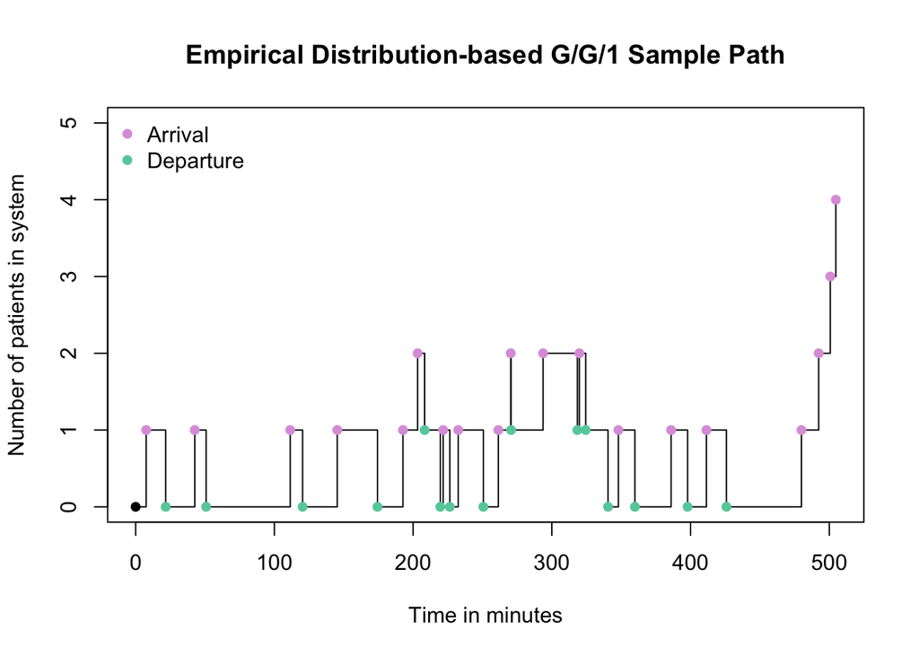

Figure 5: Sample 1-day plotting path for Empirical G/G/1 queue

Figure 5 shows the number of patients in the G/G/1 queue within the empirical distribution over time. The sample path shows that the system remains in low-congestion states for most of the simulation with patient numbers typically fluctuating between 0 and 1. There are short periods of moderate congestion that occur throughout the simulation, with the largest queue build-up appearing near the 480 to 500 minute mark where the number of patients temporarily increases to 4.

Compared to Figure 4 , this model demonstrates more scattered fluctuations and shorter congestion periods, suggesting that the empirically sampled inter-arrival and service times produce variable but generally stable system behaviour. The frequent returns to an empty system indicates periods of an idle server. Overall, the sample path suggests that while temporary queue accumulation does occur, sustained congestion is usually uncommon within the simulated healthcare system.

As such, the G/G/1 model can be re-implemented, to now sample straight from the inter-arrival times and appointment durations of the dataset, resulting in the consequent mean and maximum wait times.

Actual vs Empirical Queue Simulated Mean and Maximum Waiting times

| Metrics | Theoretical | Simulation |
| --- | --- | --- |
| Mean Wait | 44.08651 | 30.69988 |
| Max Wait | 297.30000 | 272.20000 |

Table 3: Comparison of Mean and Maximum waiting times of Actual System vs Empirical-based Queue Simulation

While both the mean and maximum waiting times have become closer to the actual values, there still remains a discrepancy between the actual and simulation values. However, the difference in mean waiting times dropping from ~19 mins to ~13 mins, does indicate a measure of misfit with the Weibull distributions.

The remaining discrepancy may be explained by the limitations present within the G/G/1 model itself. The test metrics calculated for the simulation based on empirical distributions is as follows.

Theoretical vs Empirical Distribution Based Queue Simulated Mean and Maximum Waiting times

| Metric | Theoretical | Simulated |
| --- | --- | --- |
| Utilisation | 0.9699811 | 0.7596691 |
| Avg. number in system | 14.8435417 | 2.0891671 |
| Avg. number in queue | 13.8735606 | 1.3294979 |
| Avg. response time | 267.4877467 | 37.6477932 |
| Avg. waiting time | 250.0082217 | 20.1682682 |
| System empty probability | 0.0300189 | 0.2403309 |

Table 4: Comparison of Additional Metrics of Actual System vs Empirical-based Queue Simulation

While the metrics have become marginally closer to that of the theoretical values, there still remains significant deviation, as values such as rho (~0.76) have remained highly similar. Despite an increase in average response time (W = 37.64 mins) and waiting times (Wq = 20.17) for the simulated, these are still substantially lower than the theoretical values.

However, of the two developed queuing model, using the empirical distribution to model waiting times and inter-arrival times does appear to develop a queuing system more reflective of the dataset.

**G/G/c**

By expanding the queuing system to simulate having both 2 and 3 doctors within the hospital system to manage 10,000 patients, the waiting times respond as such.

**Weibull Dependent Model:**

```r
# G/G/c Queue Simulation - Weibull

set.seed(123)

ggc_weibull <- function(c) {

  # number of patients to simulate
  sim_patients <- 10000

  # no-show generation
  attends <- rbinom(sim_patients, 1, 1 - no_show_rate)

  # system variables
  X <- 0  # number of patients in system
  B <- 0  # number of busy doctors
  T <- 0  # time

  time_vec <- c(0)
  state_vec <- c(0)
  event_vec <- c("Start")
  waiting_times <- c()

  # first arrival
  T_a <- rweibull(
    1,
    shape = shape_inter,
    scale = scale_inter
  )

  # no departures initially until first patient arrives
  departure_times <- rep(Inf, c)

  queue_arrivals <- c()

  patient <- 0

  # running loop until target patients reached
  while (patient < sim_patients) {

    next_departure <- min(departure_times)
    # find soonest departure across all servers

    # arrival event
    if (T_a < next_departure) {

      T <- T_a

      patient <- patient + 1

      # next arrival
      T_a <- T + rweibull(
        1,
        shape = shape_inter,
        scale = scale_inter
      )

      # skip no-shows
      if (attends[patient] == 0) {
        next
      }

      # log arrival event
      X <- X + 1

      event_vec <- c(event_vec, "Arrival")
      time_vec <- c(time_vec, T)
      state_vec <- c(state_vec, X)

      # free server available so patient is seen immediately
      if (B < c) {

        B <- B + 1
        waiting_times <- c(waiting_times, 0)
        # assigning patient to first available server
        free_server <- which(is.infinite(departure_times))[1]

        #generate appointment duration
        service_time <- rweibull(
          1,
          shape = shape_service,
          scale = scale_service
        )

        departure_times[free_server] <- T + service_time

      } else {

        #if all servers are busy, patient joins the queue
        queue_arrivals <- c(queue_arrivals, T)

      }

    } else {

      # patient leaves
      T <- next_departure

      server <- which.min(departure_times)

      X <- X - 1
      B <- B - 1

      event_vec <- c(event_vec, "Departure")
      time_vec <- c(time_vec, T)
      state_vec <- c(state_vec, X)

      # queue not empty, so patient assigned to freed server
      if (length(queue_arrivals) > 0) {

        next_customer <- queue_arrivals[1]

        wait <- T - next_customer

        waiting_times <- c(waiting_times, wait)

        queue_arrivals <- queue_arrivals[-1]

        B <- B + 1

        service_time <- rweibull(
          1,
          shape = shape_service,
          scale = scale_service
        )

        departure_times[server] <- T + service_time

      } else {

        # queue empty so the server becomes idle.
        departure_times[server] <- Inf

      }
    }
  }

  # return simulation results
  return (list(
    waits = waiting_times,
    events = event_vec,
    states = state_vec,
    time = time_vec
  ))
}
```

**Weibull Dependent Model Graphs:**

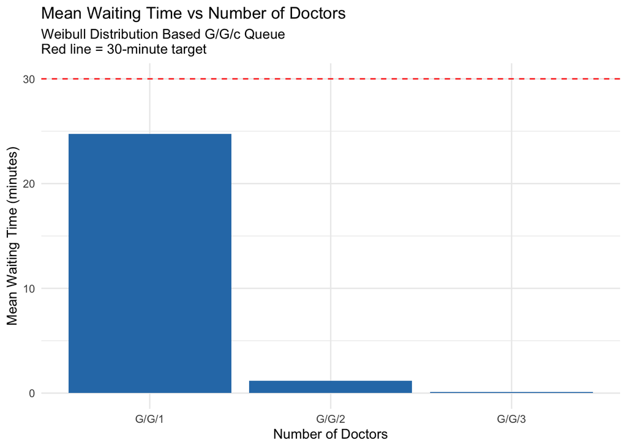

(a) Mean Waiting Time

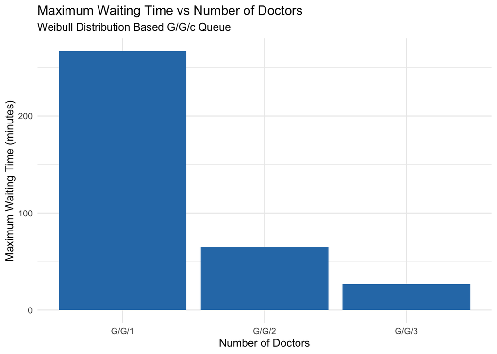

(b) Maximum Waiting Time

Figure 6: Bar graphs for mean and maximum waiting times of Weibull G/G/c queues

```r
# simulate for 1 server
gg1_w <- ggc_weibull(1)
mean_wait_w1 <- mean(gg1_w$waits)
max_wait_w1 <- max(gg1_w$waits)

# simulate for 2 servers
gg2_w <- ggc_weibull(2)
mean_wait_w2 <- mean(gg2_w$waits)
max_wait_w2 <- max(gg2_w$waits)

# simulate for 3 servers
gg3 <- ggc_weibull(3)
mean_wait_w3 <- mean(gg3$waits)
max_wait_w3 <- max(gg3$waits)

# return mean and max waiting times
weibull_waitmean <- data.frame(
  model = c("G/G/1","G/G/2","G/G/3"),
  mean_wait = c(mean_wait_w1,mean_wait_w2,mean_wait_w3)
)

weibull_waitmax <- data.frame(
  model = c("G/G/1","G/G/2","G/G/3"),
  max_wait = c(max_wait_w1,max_wait_w2,max_wait_w3)
)


library(ggplot2)

par(mfrow = c(1,2))
ggplot(weibull_waitmean, aes(x = model, y = mean_wait)) +
  geom_col(fill = "#2C7BB6") +
  geom_hline(yintercept = 30, linetype = "dashed", color = "red") +
  labs(
    title = "Mean Waiting Time vs Number of Doctors",
    subtitle = "Weibull Distribution Based G/G/c Queue\nRed line = 30-minute target",
    x = "Number of Doctors",
    y = "Mean Waiting Time (minutes)"
  ) +
  theme_minimal()

ggplot(weibull_waitmax, aes(x = model, y = max_wait)) +
  geom_col(fill = "#2C7BB6") +
  labs(
    title = "Maximum Waiting Time vs Number of Doctors",
    subtitle = "Weibull Distribution Based G/G/c Queue",
    x = "Number of Doctors",
    y = "Maximum Waiting Time (minutes)"
  ) +
  theme_minimal()
```

**Empirical Dependent G/G/C Model:**

```r
# G/G/c Queue Simulation - Empirical Distribution

set.seed(123)

emp_ggc_model <- function(c) {

  # number of patients to simulate
  sim_patients <- 10000

  # no-show generation
  attends <- rbinom(sim_patients, 1, 1 - no_show_rate)

  # system variables
  X <- 0  # number of patients in system
  B <- 0  # number of busy doctors
  T <- 0  # time

  time_vec <- c(0)
  state_vec <- c(0)
  event_vec <- c("Start")

  waiting_times <- c()

  # first arrival
  T_a <- sample(inter_arrivals, size=1, replace=TRUE)

  # no departures initially until first patient arrives
  departure_times <- rep(Inf, c)

  queue_arrivals <- c()

  patient <- 0

  #running loop until target patients reached
  while (patient < sim_patients) {

    next_departure <- min(departure_times)
    #find soonest departure across all doctors

  # arrival event
    if (T_a < next_departure) {

      T <- T_a

      patient <- patient + 1

      # next arrival
      T_a <- T + sample(inter_arrivals, size=1, replace=TRUE)

      # skip no-shows
      if (attends[patient] == 0) {
        next
      }

      X <- X + 1

      # log arrival event
      event_vec <- c(event_vec, "Arrival")
      time_vec <- c(time_vec, T)
      state_vec <- c(state_vec, X)

    # free server available so patient is seen immediately
      if (B < c) {

        B <- B + 1

        waiting_times <- c(waiting_times, 0)

        # assign patient to first available server
        free_server <- which(is.infinite(departure_times))[1]

        # generate appointment duration
        service_time <- sample(appointment_duration, size=1, replace=TRUE)

        departure_times[free_server] <- T + service_time

      } else {

        # if all servers are busy, patient joins the queue
        queue_arrivals <- c(queue_arrivals, T)

      }

    } else {

      # patient leaves
      T <- next_departure

      server <- which.min(departure_times)

      X <- X - 1
      B <- B - 1

      event_vec <- c(event_vec, "Departure")
      time_vec <- c(time_vec, T)
      state_vec <- c(state_vec, X)

      # queue not empty, so patient assigned to freed server
      if (length(queue_arrivals) > 0) {

        next_customer <- queue_arrivals[1]

        wait <- T - next_customer

        waiting_times <- c(waiting_times, wait)

        queue_arrivals <- queue_arrivals[-1]

        B <- B + 1

        service_time <- sample(appointment_duration, size=1, replace=TRUE)

        departure_times[server] <- T + service_time

      } else {

        # queue empty so server becomes idle
        departure_times[server] <- Inf

      }
    }
  }
  # return simulation results
  return (list(waits = waiting_times,
               events = event_vec,
               times = time_vec,
               states = state_vec))
}
```

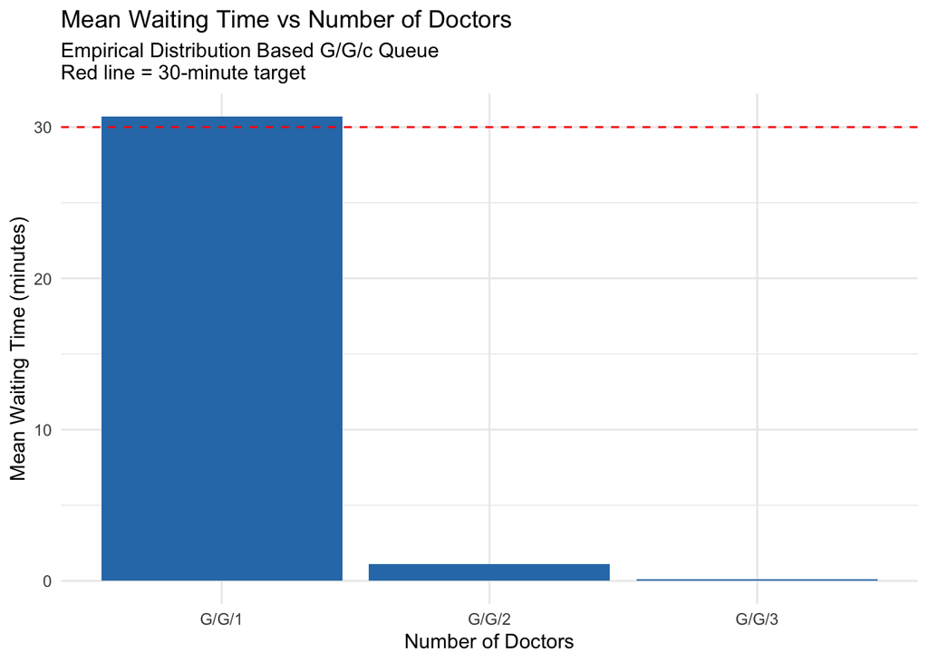

(a) Mean Waiting Time

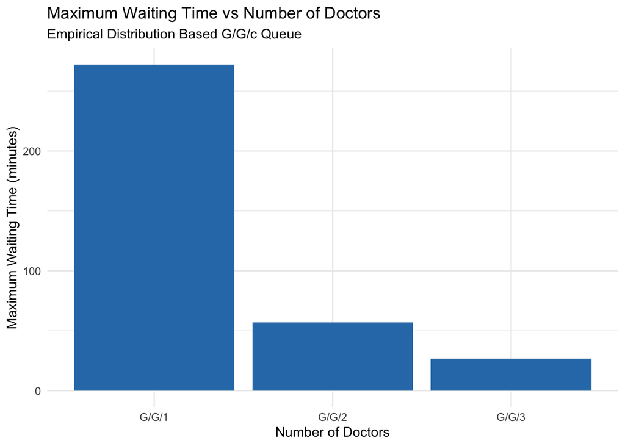

(b) Maximum Waiting Time

The observed reduction in the waiting times is non-linear, with the largest improvement occurring when increasing from one to two doctors. This occurs because the system transitions from a highly congested state to a more stable system. Once additional servers are introduced, the system becomes progressively less sensitive to the fluctuations in arrival and service processes, leading to an extreme improvement in waiting time reduction.

Employing 1 additional doctor would be enough to drastically reduce waiting times within the queuing system. However, more than 3 doctors working within the hospital would instead lead to unproductivity due to lack of constant patient in-flow.

### 3.4 Interpretation of Findings

Across all of the simulation experiments, there were several consistent patterns regarding the performance of the healthcare queueing system.

Firstly, both of the modelling approaches (Weibull and empirical sampling) produced similar qualitative behaviour, but they varied in their ability to replicate observed waiting times. Based on the metrics calculated in Table 4, the Empirical Distribution approach consistently produces results closer to the observed dataset, suggesting that it could preserve the original variability in the data is more important for accurately representing queue dynamics than fitting a smooth theoretical distribution.

Secondly, the system is highly sensitive to changes in staffing levels. Moving from a single doctor (G/G/1) to two doctors (G/G/2) produces the largest reduction in waiting times, indicating a strong non-linear improvement in system performance. However, further increases beyond three doctors yield diminishing returns, suggesting the system becomes under-utilised at higher service capacities.

Overall, the results indicate that clinic performance is heavily influenced by service capacity and variability in arrivals rather than the choice of fitted distribution alone. This highlights the importance of modelling both stochastic variability and staffing structure when evaluating healthcare systems.

## 4 Conclusion

### 4.1 Discussion of results

This project successfully developed G/G/1 and G/G/c queueing simulation models to analyse the performance of a healthcare appointment system. The simulation incorporated stochastic patient arrivals, variable appointment durations, and patient no-show behaviour to better reflect real clinical operations.

There were two approaches used to model the inter-arrival and service times: empirical sampling from the observed dataset, and fitted Weibull distributions. Although the Weibull distributions provided a statistically reasonable fit to the observed data, the empirical distribution approach produced simulation outputs that more closely resembled the real waiting time behaviour in the original dataset. The Weibull simulation was found to generate less realistic waiting time patterns and queue behaviour because the theoretical distribution couldn’t fully represent the variability and structure that was present in the real appointment data. On the other hand, the empirical sampling preserved the characteristics found in the dataset, and this resulted in more accurate and realistic simulation outcomes.

### 4.2 Strengths and limitations

One major strength of this project is the use of a simulation-based queueing approach rather than solely relying on theoretical queueing formulas. This allowed the model to incorporate realistic healthcare system behaviours such as the variable appointment durations, irregular patient arrivals and patient no-shows. The use of both G/G/1 and G/G/c models also aided with the comparison of staffing scenarios and their effect on clinic performance.

Another strength is the use of real healthcare appointment data to estimate model inputs. Through the fitting of probability distributions and comparing them against the empirical sampling approaches, the project was able to evaluate different modelling techniques and assess their realism.

One limitation of the model is its simplified representation of a real healthcare system. Since the dataset used was synthetically generated, it may not perfectly represent the complexity of a real healthcare clinic. The model also assumes that all doctors have the same efficiency in terms of service and that patients are served using a ‘first-come first-serve’ approach. Overall the model does not take into account different nuances including priority patients, emergency interruptions and varying efficiencies of doctors and healthcare staff.

The model also assumes an unlimited queue capacity and does not take account for patient behaviours such as late arrivals, rescheduling, cancellations, or patients leaving the queue before their appointment. These assumptions may reduce the realism of the simulation when compared to real-world healthcare environments.

### 4.3 Possible extensions (future work)

Several extensions could improve the realism and relevance of the model. Future work could incorporate time-dependent arrival rates to model peak clinic periods more accurately, such as increased demand in peak hours including mornings or evenings. The model could also work to include patient behaviours such as late arrivals, rescheduling, cancellations, or priority-based triage systems.

The model could be further extended by introducing doctors with different services or specialities, allowing the simulation to better represent a real hospital environment. Future studies could also be done to compare additional probability distributions or hybrid approaches to combine both empirical and theoretical methods.

Another possible extension could be to investigate appointment scheduling optimisation by testing different booking strategies and their impact on queue congestion and patient waiting times.

### 4.4 Practical implications

The findings of this project demonstrate the usefulness of queueing simulation for healthcare planning and resource allocation. The results show that increasing the number of available doctors can substantially reduce patient waiting times and improve overall system performance.

The project also highlights the importance of selecting appropriate modelling techniques when developing healthcare simulations. Although theoretical probability distributions are mathematically convenient, empirical approaches may provide more realistic representations of healthcare systems when there is a sufficient amount of data available.

Overall, this simulation framework could assist healthcare administrators in evaluating staffing decisions, reducing patient congestion, improving appointment scheduling systems, and increasing the operational efficiency within clinics and hospitals.

## 5 Contributions

**Proposal:** All

**Introduction and Background:** Rithika, Harshitha

**Methodology:** Harshitha, Kesia, Rithika

**Model Implementation and Results:** Kesia, Harshitha

**Conclusion:** Harshitha

**Coding:** Kesia, Harshitha, Rithika

## 6 References

Alrasheedi, K. F., AL-Mohaithef, M., Edrees, H. H., & Chandramohan, S. (2019). The Association Between Wait Times and Patient Satisfaction: Findings From Primary Health Centers in the Kingdom of Saudi Arabia. *Health Services Research and Managerial Epidemiology*, 6(1), 233339281986124. https://doi.org/10.1177/2333392819861246

Cameron, A. (2024) *R: How to Simulate a Queue*. Stack Overflow. https://stackoverflow.com/questions/77734912/r-how-to-simulate-a-queue

Dantas, L. F., Fleck, J. L., Cyrino Oliveira, F. L., & Hamacher, S. (2018). No-shows in appointment scheduling – a systematic literature review. *Health Policy,* 122(4), 412–421. https://doi.org/10.1016/j.healthpol.2018.02.002

Gupta, D., Denton, B. (2006). Appointment scheduling in health care: Challenges and opportunities. *IIE Transactions, 40*(9), 800–819. https://doi.org/10.1080/07408170802165880

Jain, M. *Beginner’s Guide to Queue Management System for Hospitals and Clinics*. Pickcel. https://www.pickcel.com/blog/images/what-is-a-queue-management-system-for-hospitals.webp

Osorio, F. O., Gomez, S. P., Esteban, D., Fernandez, R. R., Reinel Tabares-Soto, Bravo-Ortíz, M. A., & Adolfo, G. (2025). Predicting non-shows at outpatient appointments in internal medicine using machine learning models. *PeerJ Computer Science*, 11, e2762–e2762. https://doi.org/10.7717/peerj-cs.2762

Roser, C. (2017). *The Kingman Formula – Variation, Utilization, and Lead Time.* All About Lean. https://www.allaboutlean.com/kingman-formula/

Samel, M. (2025). *The Impact of Staff Shortage in Healthcare on Workers and Patients - Parim Workforce Software*. Parim.co. https://www.parim.co/blog/impact-of-staff-shortage-in-healthcare

Wiwatanapataphee, S. (2026). *EV Charging Bays Simulation* [Quarto Notebook]. R and Python for Computer Simulation. https://zamnolence.github.io/_book/10_4_EVbays.html

Wiwatanapataphee, S. (2026). *Markov Process* [Quarto Notebook]. R and Python for Computer Simulation. https://zamnolence.github.io/_book/06_3_markov.html